# UW Data Science - Methods of Data Analysis

## Dave Wine 8430191

## Assignment 1: Building Energy Efficiency Analysis

# Summary:

The graph below summarizes the important discoveries so far:

1. Tall buildings have lower surface area than short buildings.
2. Heating Loads of tall buildings and short buildings are clustered in two distinct areas - short buildings generally run less than 15, and tall buildings are between 15 and 40.
3. Glazing Area appears to have the next strongest effect on Heating Load. Larger Glazing Area generally implies higher Heating Load.

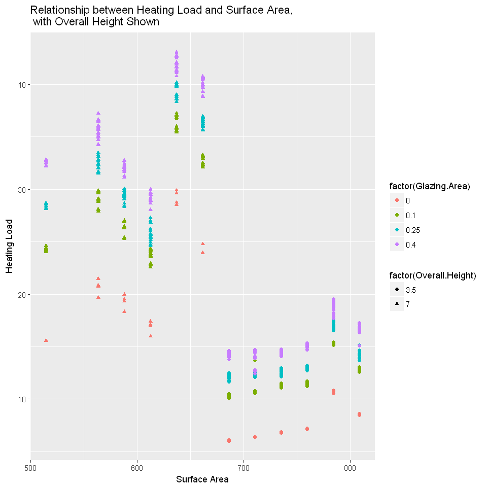

```r
ggplot(bldg.data, aes(Surface.Area, Heating.Load)) + geom_point(aes(color = factor(Glazing.Area),shape = factor(Overall.Height))) +
       xlab('Surface Area') + ylab('Heating Load') +
       ggtitle('Relationship between Heating Load and Surface Area, \n with Overall Height Shown')
```

Note: I spent much time getting up to speed on ggplot, GitHub, and various R functions. There is a lot more here I would like to do, including normalization. But this is what I was able to do so far!

# Main Analysis:

First, read in necessary packages:

```r
require(ggplot2)
require(car)
```

Define some useful functions - First, a file read function

```r
read.bldg = function(file = 'EnergyEfficiencyData.csv'){

bldg.data <- read.csv(file, header=TRUE, stringsAsFactors=FALSE)

factcols <- c('Orientation','Glazing.Area.Distribution')

bldg.data[, factcols]<-lapply(bldg.data[,factcols], as.numeric)

bldg.data[complete.cases(bldg.data),]
    }
```

2D Scatterplot function This works OK but I haven't figured out how to pass or infer labels yet....

```r
plots.2DS=function(x,y,c){
ggplot(bldg.data, aes(x, y)) + geom_point(aes(color = factor(c)))
  #+
  #xlab(x) + ylab(y) +
  #ggtitle('Relationship between'+ x +' and ' + y +' \n with '+c+' Shown')
}
```

Read the data file in and view summary statistics:

```r
bldg.data = read.bldg()


str(bldg.data)
summary(bldg.data)
```

```
'data.frame':	768 obs. of  10 variables:
 $ Relative.Compactness     : num  0.98 0.98 0.98 0.98 0.9 0.9 0.9 0.9 0.86 0.86 ...
 $ Surface.Area             : num  514 514 514 514 564 ...
 $ Wall.Area                : num  294 294 294 294 318 ...
 $ Roof.Area                : num  110 110 110 110 122 ...
 $ Overall.Height           : num  7 7 7 7 7 7 7 7 7 7 ...
 $ Orientation              : num  2 3 4 5 2 3 4 5 2 3 ...
 $ Glazing.Area             : num  0 0 0 0 0 0 0 0 0 0 ...
 $ Glazing.Area.Distribution: num  0 0 0 0 0 0 0 0 0 0 ...
 $ Heating.Load             : num  15.6 15.6 15.6 15.6 20.8 ...
 $ Cooling.Load             : num  21.3 21.3 21.3 21.3 28.3 ...
```

```
 Relative.Compactness  Surface.Area     Wall.Area       Roof.Area
 Min.   :0.6200       Min.   :514.5   Min.   :245.0   Min.   :110.2
 1st Qu.:0.6825       1st Qu.:606.4   1st Qu.:294.0   1st Qu.:140.9
 Median :0.7500       Median :673.8   Median :318.5   Median :183.8
 Mean   :0.7642       Mean   :671.7   Mean   :318.5   Mean   :176.6
 3rd Qu.:0.8300       3rd Qu.:741.1   3rd Qu.:343.0   3rd Qu.:220.5
 Max.   :0.9800       Max.   :808.5   Max.   :416.5   Max.   :220.5
 Overall.Height  Orientation    Glazing.Area    Glazing.Area.Distribution
 Min.   :3.50   Min.   :2.00   Min.   :0.0000   Min.   :0.000
 1st Qu.:3.50   1st Qu.:2.75   1st Qu.:0.1000   1st Qu.:1.750
 Median :5.25   Median :3.50   Median :0.2500   Median :3.000
 Mean   :5.25   Mean   :3.50   Mean   :0.2344   Mean   :2.812
 3rd Qu.:7.00   3rd Qu.:4.25   3rd Qu.:0.4000   3rd Qu.:4.000
 Max.   :7.00   Max.   :5.00   Max.   :0.4000   Max.   :5.000
  Heating.Load    Cooling.Load
 Min.   : 6.01   Min.   :10.90
 1st Qu.:12.99   1st Qu.:15.62
 Median :18.95   Median :22.08
 Mean   :22.31   Mean   :24.59
 3rd Qu.:31.67   3rd Qu.:33.13
 Max.   :43.10   Max.   :48.03
```

Initial Observations: Overall Height, Orientation, Glazing Area Distribution seem to be numerical factors rather than data per se.

Create factors for appropriate variables

```r
factOrient <- cut(bldg.data$Orientation,breaks=4,labels=1:4)

factDist <- cut(bldg.data$Glazing.Area.Distribution,breaks=6,labels=1:6)

factHeight <- cut(bldg.data$Overall.Height,breaks=2,labels=1:2)
```

Next, look at overall variable correlations

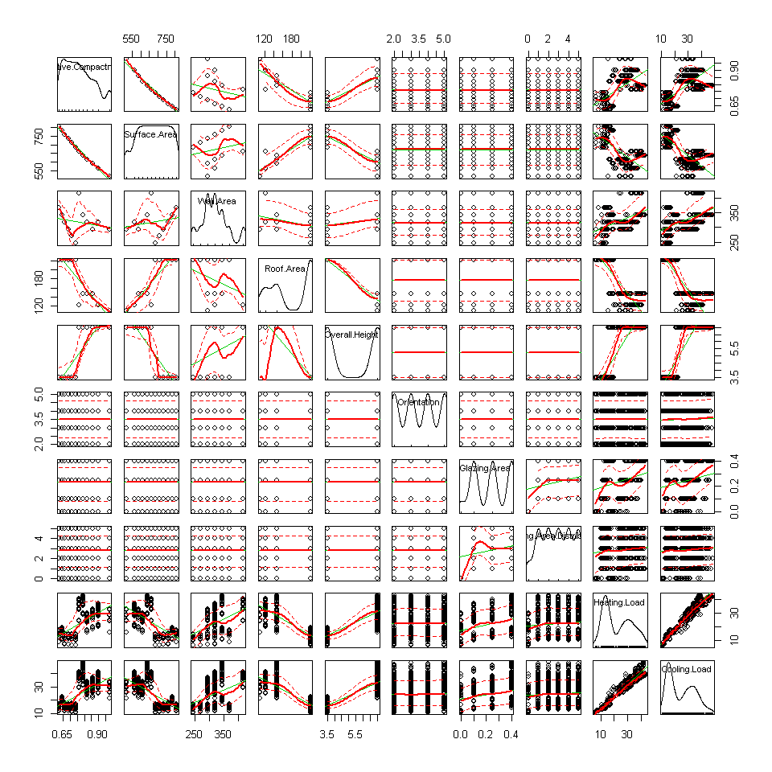

```r
options(repr.plot.width=8, repr.plot.height=8)
scatterplotMatrix(~ Relative.Compactness + Surface.Area + Wall.Area + Roof.Area +
Overall.Height + Orientation + Glazing.Area + Glazing.Area.Distribution + Heating.Load + Cooling.Load, data = bldg.data)
```

## Some Observations:

Heating and Cooling Loads are very similar and obviously bimodal. Neither appear to depend strongly on Orientation or Glazing Area Distribution. Maybe there is a weak linear dependence on Glazing Area Notice that Overall Height and Roof Area are sort of inversely correlated to Wall Area. Looks sort of cubic.

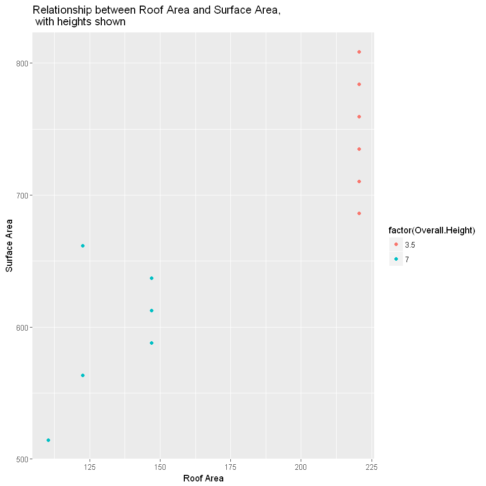

```r
ggplot(bldg.data, aes(Roof.Area, Surface.Area)) + geom_point(aes(color = factor(Overall.Height))) +
  xlab('Roof Area') + ylab('Surface Area') +
  ggtitle('Relationship between Roof Area and Surface Area, \n with heights shown')
```

Short buildings all have the same roof area. Let's split the dataset into tall and short buildings:

```r
Short<-subset(bldg.data,Overall.Height==3.5)
str(Short)
Tall<-subset(bldg.data,Overall.Height==7)
str(Tall)
```

```
'data.frame':	384 obs. of  10 variables:
 $ Relative.Compactness     : num  0.74 0.74 0.74 0.74 0.71 0.71 0.71 0.71 0.69 0.69 ...
 $ Surface.Area             : num  686 686 686 686 710 ...
 $ Wall.Area                : num  245 245 245 245 270 ...
 $ Roof.Area                : num  220 220 220 220 220 ...
 $ Overall.Height           : num  3.5 3.5 3.5 3.5 3.5 3.5 3.5 3.5 3.5 3.5 ...
 $ Orientation              : num  2 3 4 5 2 3 4 5 2 3 ...
 $ Glazing.Area             : num  0 0 0 0 0 0 0 0 0 0 ...
 $ Glazing.Area.Distribution: num  0 0 0 0 0 0 0 0 0 0 ...
 $ Heating.Load             : num  6.07 6.05 6.01 6.04 6.37 6.4 6.37 6.4 6.85 6.79 ...
 $ Cooling.Load             : num  10.9 11.2 10.9 11.2 11.3 ...
'data.frame':	384 obs. of  10 variables:
 $ Relative.Compactness     : num  0.98 0.98 0.98 0.98 0.9 0.9 0.9 0.9 0.86 0.86 ...
 $ Surface.Area             : num  514 514 514 514 564 ...
 $ Wall.Area                : num  294 294 294 294 318 ...
 $ Roof.Area                : num  110 110 110 110 122 ...
 $ Overall.Height           : num  7 7 7 7 7 7 7 7 7 7 ...
 $ Orientation              : num  2 3 4 5 2 3 4 5 2 3 ...
 $ Glazing.Area             : num  0 0 0 0 0 0 0 0 0 0 ...
 $ Glazing.Area.Distribution: num  0 0 0 0 0 0 0 0 0 0 ...
 $ Heating.Load             : num  15.6 15.6 15.6 15.6 20.8 ...
 $ Cooling.Load             : num  21.3 21.3 21.3 21.3 28.3 ...
```

So the data set is evenly split between tall and short buildings. All short buildings have the same roof area. This implies some standard kind of building. Since there is variation in heating load:

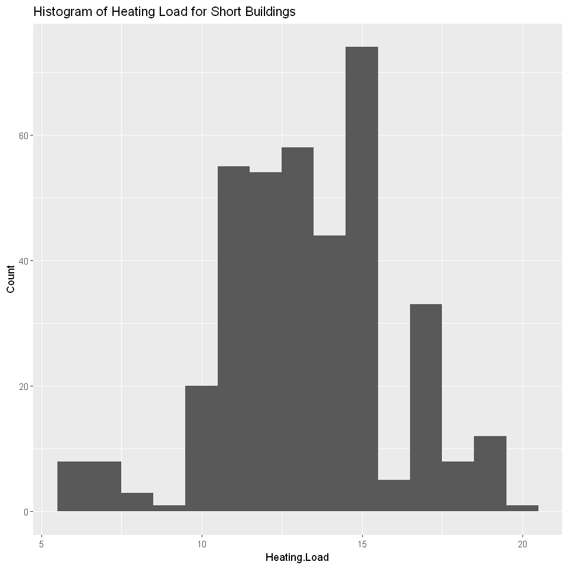

```r
ggplot(Short, aes(Heating.Load)) + geom_histogram(binwidth = 1) +
xlab('Heating.Load') + ylab('Count')+ ggtitle('Histogram of Heating Load for Short Buildings')
```

For short buildings, the heating load does not seem to be strongly dependent on Surface Area:

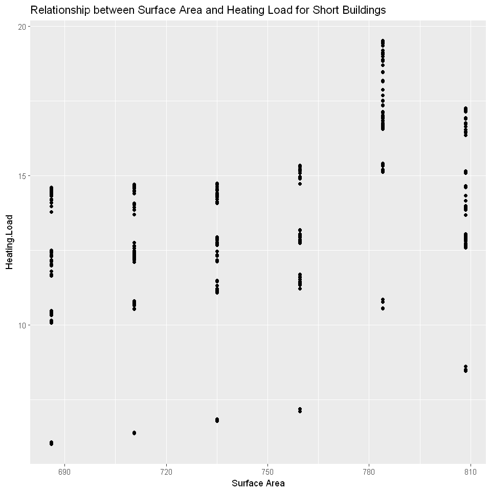

```r
ggplot(Short, aes(x = Surface.Area, y = Heating.Load)) + geom_point() +
  xlab('Surface Area') + ylab('Heating.Load') +
  ggtitle('Relationship between Surface Area and Heating Load for Short Buildings')
```

It's also interesting to note that Surface Area is pretty discretized. This may imply that short buildings have some discrete multiplier, maybe they have discrete heights. But it's confusing because of the change at 780, and because the height variable implies they are all the same height. More info on the dataset or a different cut is needed here.

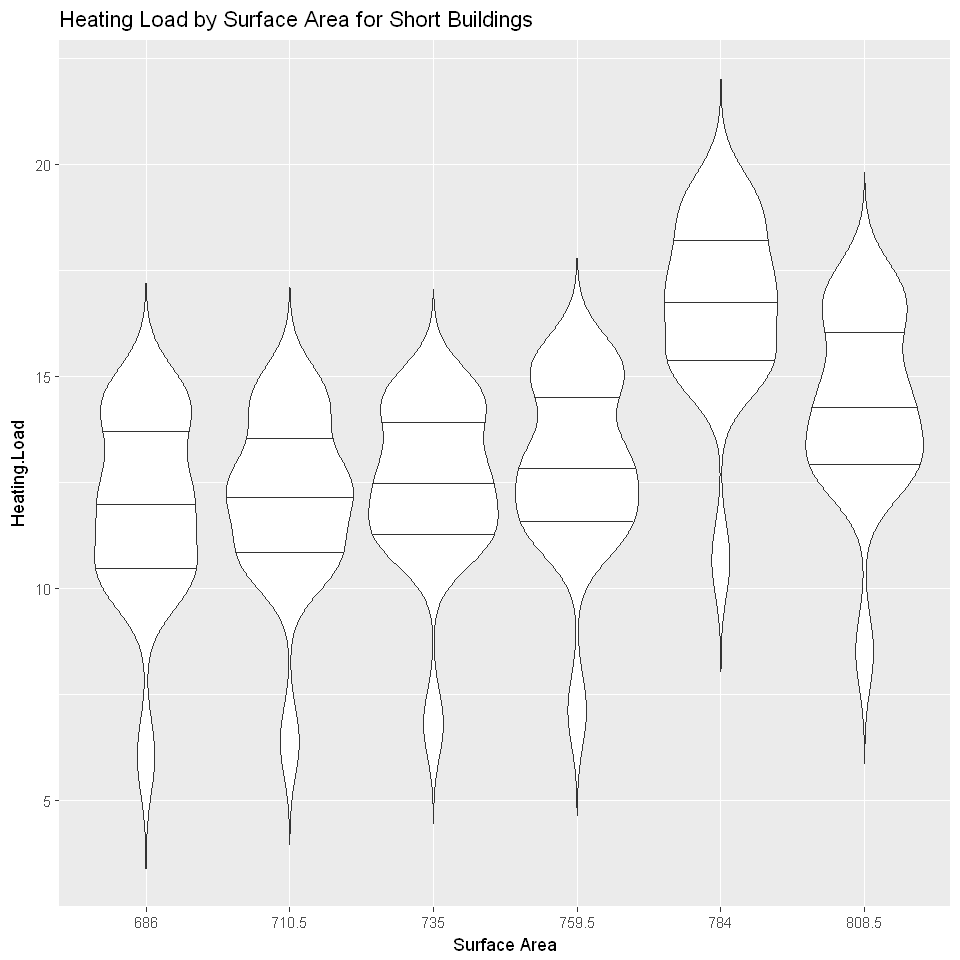

```r
ggplot(Short, aes(x = factor(Surface.Area), y = Heating.Load)) +
  geom_violin(trim = FALSE, draw_quantiles = c(0.25, 0.5, 0.75)) + xlab('Surface Area')  +
  ggtitle('Heating Load by Surface Area for Short Buildings')
```

But rather than pursue that, I decided to look at the clustering within each group in Surface Area. The violin plot above shows a general similarity, which indicates to me some other relationship. I tried glazing area as a possible factor:

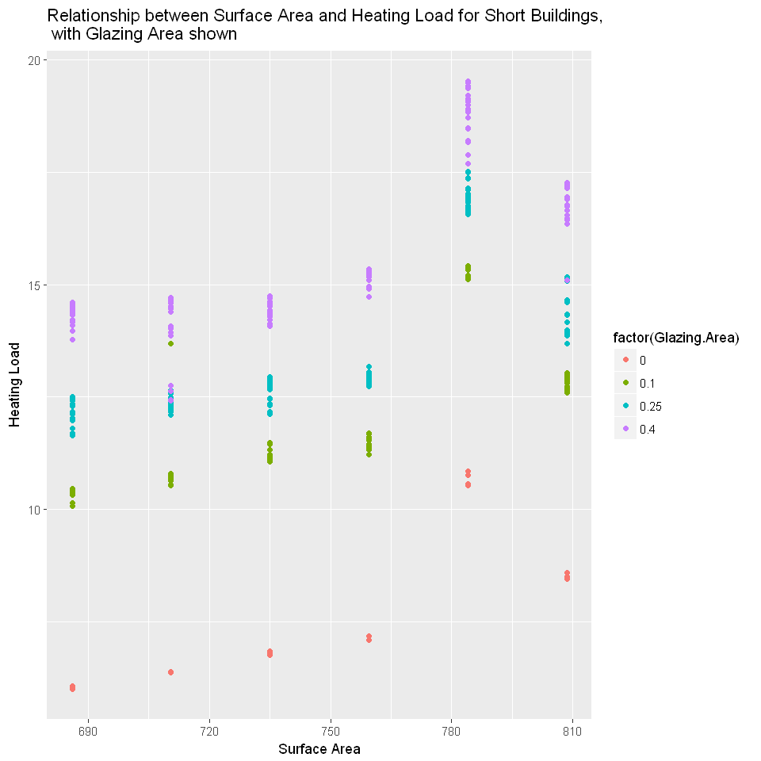

```r
ggplot(Short, aes(Surface.Area, Heating.Load)) + geom_point(aes(color = factor(Glazing.Area))) +
  xlab('Surface Area') + ylab('Heating Load') +
  ggtitle('Relationship between Surface Area and Heating Load for Short Buildings, \n with Glazing Area shown')
```

So Heating Load seems to be positively correlated to Glazing Area more than Surface Area. Given that windows are in general more thermally conductive than walls, this makes sense. The cluster at around 780 must have something else going on. Looking at just the buildings without windows (Glazing Area = 0), is there anything else obvious going on?

```
 Relative.Compactness  Surface.Area     Wall.Area       Roof.Area
 Min.   :0.7600       Min.   :514.5   Min.   :294.0   Min.   :110.2
 1st Qu.:0.7900       1st Qu.:563.5   1st Qu.:294.0   1st Qu.:122.5
 Median :0.8400       Median :600.2   Median :318.5   Median :134.8
 Mean   :0.8517       Mean   :596.2   Mean   :330.8   Mean   :132.7
 3rd Qu.:0.9000       3rd Qu.:637.0   3rd Qu.:343.0   3rd Qu.:147.0
 Max.   :0.9800       Max.   :661.5   Max.   :416.5   Max.   :147.0
 Overall.Height  Orientation    Glazing.Area Glazing.Area.Distribution
 Min.   :7      Min.   :2.00   Min.   :0     Min.   :0
 1st Qu.:7      1st Qu.:2.75   1st Qu.:0     1st Qu.:0
 Median :7      Median :3.50   Median :0     Median :0
 Mean   :7      Mean   :3.50   Mean   :0     Mean   :0
 3rd Qu.:7      3rd Qu.:4.25   3rd Qu.:0     3rd Qu.:0
 Max.   :7      Max.   :5.00   Max.   :0     Max.   :0
  Heating.Load    Cooling.Load
 Min.   :15.55   Min.   :21.16
 1st Qu.:17.02   1st Qu.:21.84
 Median :19.82   Median :26.34
 Mean   :20.98   Mean   :26.82
 3rd Qu.:24.14   3rd Qu.:29.71
 Max.   :29.90   Max.   :39.44
```

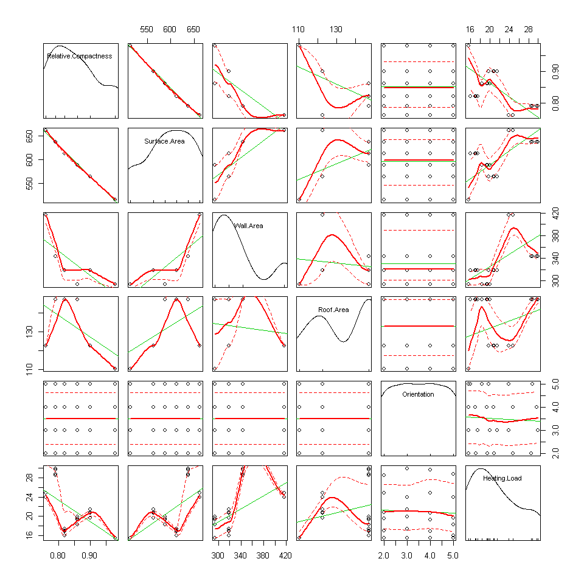

```r
Tall.Dark<-subset(Tall,Glazing.Area==0)
summary(Tall.Dark)

options(repr.plot.width=8, repr.plot.height=8)
scatterplotMatrix(~ Relative.Compactness + Surface.Area + Wall.Area + Roof.Area +
                    Orientation  +  Heating.Load, data = Tall.Dark)
```

Orientation does not seem be a big factor. There are still interesting outliers in the Surface Area plots at around 625. Roof Area seems to affect heating load less than wall area, but not in any clear way.

Looking back at the entire data set, what can we learn about heating load from Surface Area?

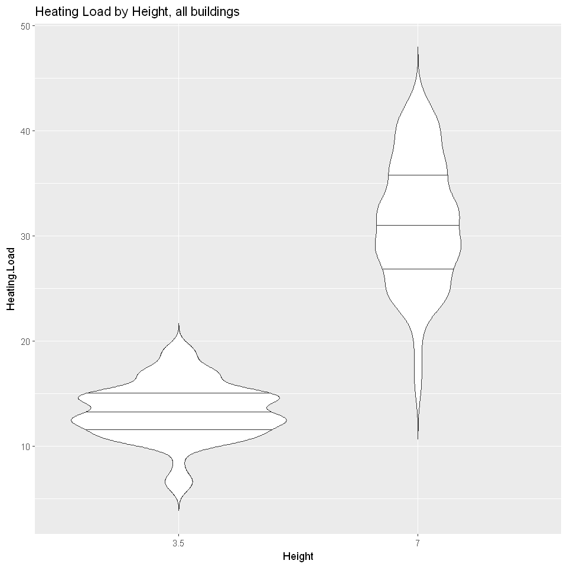

```r
ggplot(bldg.data, aes(x = factor(Overall.Height), y = Heating.Load)) +
  geom_violin(trim = FALSE, draw_quantiles = c(0.25, 0.5, 0.75)) + xlab('Height')  +
  ggtitle('Heating Load by Height, all buildings')
```

This clearly shows the two distinct populations of buildings.

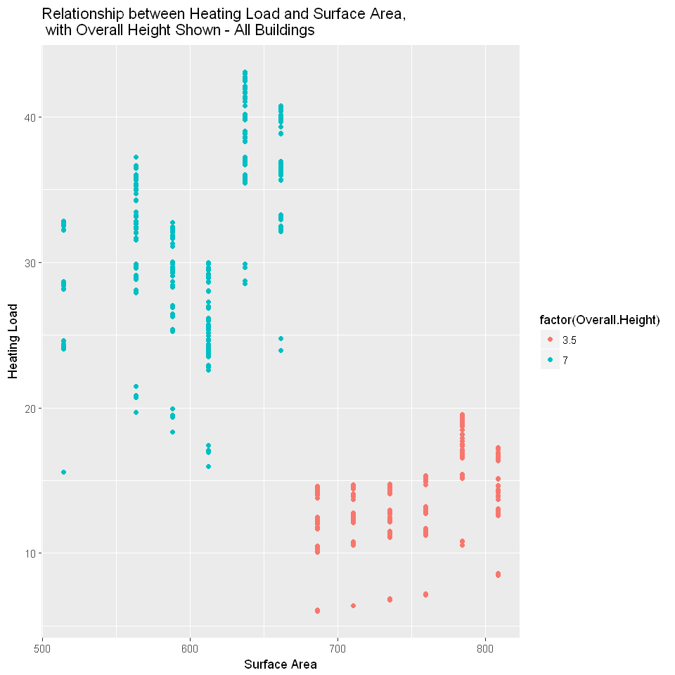

```r
ggplot(bldg.data, aes(Surface.Area, Heating.Load)) + geom_point(aes(color = factor(Overall.Height))) +
  xlab('Surface Area') + ylab('Heating Load') +
  ggtitle('Relationship between Heating Load and Surface Area, \n with Overall Height Shown - All Buildings')
```

There are two obvious clusters, one of which is the short building cluster we just studied. There are apparently more effects present in the tall building subset. Generally, tall buildings have a higher heating load.

If we add Glazing Area into the picture, we see an overall picture:

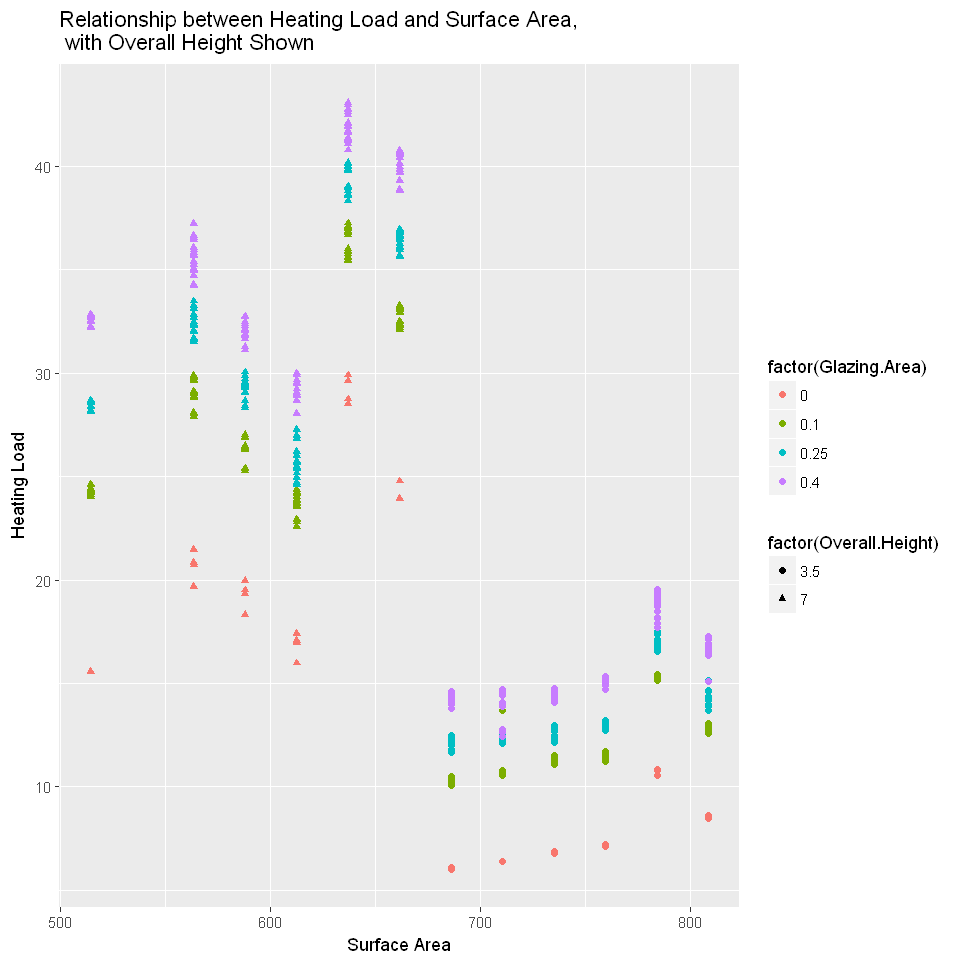

```r
ggplot(bldg.data, aes(Surface.Area, Heating.Load)) + geom_point(aes(color = factor(Glazing.Area),shape = factor(Overall.Height))) +
       xlab('Surface Area') + ylab('Heating Load') +
       ggtitle('Relationship between Heating Load and Surface Area, \n with Overall Height Shown')
```

This graph summarizes the important discoveries so far:

1. Tall buildings have lower surface area than short buildings.
2. Heating Loads of tall buildings and short buildings are clustered in two distinct areas - short buildings generally run less than 15, and tall buildings are between 15 and 40.
3. Glazing Area appears to have the next strongest effect on Heating Load. Larger Glazing Area generally implies higher Heating Load.